# Lab 3

Aleksi Patronen

2024-02-01

# Assignment 1: Multi-dimensional optimization

a). The purpose of this assignment is to compare some common methods for multi-dimensional optimization. The methods will be evaluated on Himmelblau’s function f(x,y)=(x<sup>2+y-11)</sup>2+(x+y<sup>2-7)</sup>2 which has one global maximum and four local minimum (https://en.wikipedia.org/wiki/Himmelblau%27s_function). First, use the Newton method in the nlm() function with two different starting values[(0,-2); (1,1)] to perform function minimization. The next step is to analyse the same function with three methods (Conjugate-Gradient and L-BFGS-B) available in the optim() function in R. Use the two different sets of starting values as earlier for each method. Make sure that you read the documentation of this function so you can verify that convergence has been reached, it may be necessary to alter the parameters of the control option. Present three function plots (one for each method), trajectories and the final estimates.

```r
#Def. the function itself
H <- function(sta){
  x <- sta[1]
  y <- sta[2]
  (x^2+y-11)^2+(x+y^2-7)^2
  }
# starting position
p1 <- array(c(0, -2), dim = c(2, 1))
nlm(H, p1)
```

```
## $minimum
## [1] 1.722041e-10
##
## $estimate
## [1]  3.584427 -1.848127
##
## $gradient
## [1] -1.344218e-07  7.240429e-08
##
## $code
## [1] 1
##
## $iterations
## [1] 10
```

This one finds one of the minimums quite close. only some 1.722.. of an tenth of an billion away from zero.

```r
p2 <- array(c(1, 1), dim = c(2, 1))
nlm(H, p2)
```

```
## $minimum
## [1] 1.450383e-14
##
## $estimate
## [1] 3 2
##
## $gradient
## [1] -3.796284e-07 -1.532511e-07
##
## $code
## [1] 2
##
## $iterations
## [1] 10
```

This one finds the true zero (3,2) but doesn’t calculate the estimate true. It should be zero, but is given as 1.450383e-14, which is quite close.

Using given code to plot the convergence of nlm.

```r
source("C:/Users/Aleksi/Desktop/KOulu/Simulation Methods/Exercises/exercise 3/Lab3_1.R")
```

[figure not shown]

```r
optim(fn = H, par = p1, gr = "CG")
```

```
## $par
##           [,1]
## [1,]  3.584252
## [2,] -1.848195
##
## $value
## [1] 1.785882e-06
##
## $counts
## function gradient
##       69       NA
##
## $convergence
## [1] 0
##
## $message
## NULL
```

```r
optim(fn = H, par = p2, gr = "CG")
```

```
## $par
##          [,1]
## [1,] 2.999995
## [2,] 2.000183
##
## $value
## [1] 5.56163e-07
##
## $counts
## function gradient
##       67       NA
##
## $convergence
## [1] 0
##
## $message
## NULL
```

```r
optim(fn = H, par = p1, gr = "L-BFGS-B")
```

```
## $par
##           [,1]
## [1,]  3.584252
## [2,] -1.848195
##
## $value
## [1] 1.785882e-06
##
## $counts
## function gradient
##       69       NA
##
## $convergence
## [1] 0
##
## $message
## NULL
```

```r
optim(fn = H, par = p2, gr = "L-BFGS-B")
```

```
## $par
##          [,1]
## [1,] 2.999995
## [2,] 2.000183
##
## $value
## [1] 5.56163e-07
##
## $counts
## function gradient
##       67       NA
##
## $convergence
## [1] 0
##
## $message
## NULL
```

b). The next step is to analyse the same function with stochastic gradient descent. Use the two different sets of starting values as in a). for the SGD implementation following the lecture notes. Present a new plot. Compare and discuss the results from b). with these from a).

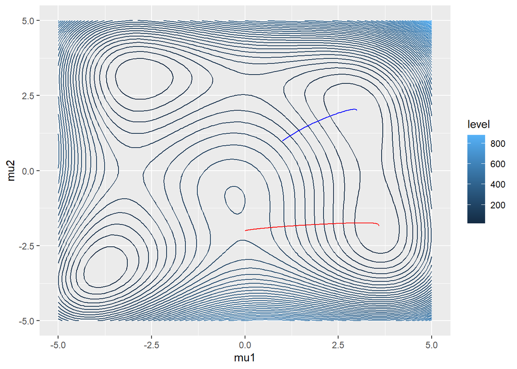

```r
#install.packages("numDeriv")

gridxy = as.matrix(expand.grid(x = seq(-5,5,0.1), y = seq(-5,5,0.1)))
likeval = apply(gridxy,1,H)
likedf = data.frame(gridxy,likeval)
colnames(likedf) = c("mu1","mu2","H")

library(numDeriv)
{#Initial parameters
    diff = 1
    iter = 1
    x = c(0,-2)
    xgdold = matrix(1,ncol=2,nrow=1000)
    #Learning rate
    lr = 0.001

    #Gradient descent with automatic stopping
    while (diff>10^-4){
      xgdold[iter,] = x
      grad = grad(func=H,x=x)
      x = x - lr*grad
      diff = sum(abs(x - xgdold[iter,]))/2
      iter=iter+1
    }
    iter
    #Collect parameter estimates in data frame
    optpathgd = data.frame(xgdold[1:(iter-1),])
    colnames(optpathgd) = c("mu1est1","mu2est1")

}


library(ggplot2)
#AGAIN WITH STARTING VALUES (1,1)
#Initial parameters
{
  diff = 1
  iter = 1
  x = c(1,1)
  xgdold = matrix(1,ncol=2,nrow=1000)
  #Learning rate
  lr = 0.001

  #Gradient descent with automatic stopping
  while (diff>10^-4){
    xgdold[iter,] = x
    grad = grad(func=H,x=x)
    x = x - lr*grad
    diff = sum(abs(x - xgdold[iter,]))/2
    iter=iter+1
  }
  iter
  #Collect parameter estimates in data frame
  optpathgd1 = data.frame(xgdold[1:(iter-1),])
  colnames(optpathgd1) = c("mu1est1","mu2est1")
}


library(ggplot2)
mixt_pl <- ggplot(likedf)
mixt_pl +
    stat_contour(aes(x = mu1, y = mu2,
    z = H,colour = after_stat(level)),bins=50)+
    geom_path(data = optpathgd,aes(x = mu1est1,
    y = mu2est1),colour="red")+
    geom_path(data = optpathgd1,aes(x = mu1est1,
    y = mu2est1),colour="blue")
```

Stochastic gradient decent took a long time, almost 160 steps. This is most likely because of (too) small of an learning rate.

```r
head(optpathgd1)
```

|  | mu1est1 | mu2est1 |
| --- | --- | --- |
| 1 | 1.000000 | 1.000000 |
| 2 | 1.046000 | 1.038000 |
| 3 | 1.092856 | 1.075983 |
| 4 | 1.140516 | 1.113884 |
| 5 | 1.188921 | 1.151633 |
| 6 | 1.238004 | 1.189163 |

```r
#it goes for 151 more steps for 157 in total.
```

# Assignment 2: Simulated Annealing and Genetic Algorithms

a). The data set housing.txt contains data on 13 socio-economic variables that are assumed to influence the median housing price (MEDV) in a region in USA. The first task is to implement R code for variable selection in a linear model using simulated annealing. The BIC criterion should be used as test statistic. A reasonable temperature schedule should be chosen. Provide a plot of the BIC statistic over iterations and the selected variables in the final model.

```r
housing <- read.csv("C:/Users/Aleksi/Desktop/KOulu/Simulation Methods/Exercises/exercise 3/housing.txt", sep="")
head(housing, 3)
```

|  | OBS. | TOWN | TOWN. | TRACT | LON | LAT | MEDV | CMEDV | CRIM | ZN | INDUS | CHAS | NOX | RM | AGE | DIS | RAD | TAX | PTRATIO | B | LSTAT |
| --- | --- | --- | --- | --- | --- | --- | --- | --- | --- | --- | --- | --- | --- | --- | --- | --- | --- | --- | --- | --- | --- |
| 1 | 1 | Nahant | 0 | 2011 | -70.955 | 42.2550 | 24.0 | 24.0 | 0.00632 | 18 | 2.31 | 0 | 0.538 | 6.575 | 65.2 | 4.0900 | 1 | 296 | 15.3 | 396.90 | 4.98 |
| 2 | 2 | Swampscott | 1 | 2021 | -70.950 | 42.2875 | 21.6 | 21.6 | 0.02731 | 0 | 7.07 | 0 | 0.469 | 6.421 | 78.9 | 4.9671 | 2 | 242 | 17.8 | 396.90 | 9.14 |
| 3 | 3 | Swampscott | 1 | 2022 | -70.936 | 42.2830 | 34.7 | 34.7 | 0.02729 | 0 | 7.07 | 0 | 0.469 | 7.185 | 61.1 | 4.9671 | 2 | 242 | 17.8 | 392.83 | 4.03 |

```r
housing_data <- housing[7:21]
attach(housing_data)
summary(lm(MEDV~ ., data = housing_data))
```

```
##
## Call:
## lm(formula = MEDV ~ ., data = housing_data)
##
## Residuals:
##     Min      1Q  Median      3Q     Max
## -6.9428 -0.0810  0.0023  0.0850  4.8294
##
## Coefficients:
##               Estimate Std. Error t value Pr(>|t|)
## (Intercept) -2.315e+00  4.258e-01  -5.436 8.58e-08 ***
## CMEDV        1.016e+00  4.461e-03 227.855  < 2e-16 ***
## CRIM         3.284e-05  3.719e-03   0.009   0.9930
## ZN          -1.703e-03  1.548e-03  -1.101   0.2716
## INDUS       -1.457e-03  6.875e-03  -0.212   0.8322
## CHAS         1.788e-02  9.727e-02   0.184   0.8542
## NOX          8.570e-01  4.152e-01   2.064   0.0396 *
## RM           3.322e-02  5.051e-02   0.658   0.5111
## AGE         -3.147e-04  1.451e-03  -0.217   0.8283
## DIS          8.597e-02  2.178e-02   3.947 9.07e-05 ***
## RAD         -6.435e-03  7.415e-03  -0.868   0.3859
## TAX          3.458e-04  4.263e-04   0.811   0.4177
## PTRATIO      3.501e-02  6.929e-03   5.053 6.14e-07 ***
## B           -4.908e-05  3.042e-04  -0.161   0.8719
## LSTAT        2.251e-02  5.464e-03   4.120 4.45e-05 ***
## ---
## Signif. codes:  0 '***' 0.001 '**' 0.01 '*' 0.05 '.' 0.1 ' ' 1
##
## Residual standard error: 0.5322 on 491 degrees of freedom
##   (2 observations deleted due to missingness)
## Multiple R-squared:  0.9968, Adjusted R-squared:  0.9967
## F-statistic: 1.093e+04 on 14 and 491 DF,  p-value: < 2.2e-16
```

```r
## DATA AND INITIAL VALUES
pred <- housing_data[-1:-2] #
y <- housing_data[1]


n <- nrow(housing_data)

ptot <- length(pred[1,]) # NUMBER OF PREDICTORS
m <- c(rep(60,5),rep(120,5),rep(220,5)) # THREE STAGE LENGTHS
tau.start <- 1
tau <- rep(tau.start,15)
bics <- NULL
```

Excluding CMEDV.

```r
set.seed(12345)
run <- rbinom(ptot,1,.5) # SAMPLE INDICATOR FOR PREDICTORS
run.current <- run
run.vars <- pred[,run.current==1] #SELECT PREDICTORS BASED ON INDICATORS
run.vars <- as.matrix(run.vars)
y <- as.matrix(y)
f <- lm(y ~ run.vars)# INITIAL LINEAR MODEL
#run.bic <- BIC(f)[2] # EXTRACT BIC
run.bic <- BIC(f) # EXTRACT BIC
best.bic <- run.bic
bics <- run.bic


positions <- matrix(ncol = ptot, nrow=1600)
k = 1
positions[k,] <- run
for(j in 2:13){tau[j] <- 0.9*tau[j-1]} #TEMP SCHEDULE 15 LEVELS
  ## SIMULATED ANNEALING

for(j in 1:13){# RANDOMLY SELECTS A PREDICTOR TO ADD/REMOVE FROM THE MODEL
  # AND ACCEPTS THE NEW MODEL IF IT IS BETTER OR WITH PROBABILITY prob
  for(i in 1:m[j]){
    pos <- sample(1:ptot,1)
    run.step <- run.current
    k = k + 1
    positions[k,] <- run.step

    run.step[pos] <- !run.current[pos]
    run.vars <- pred[,run.step==1]
    run.vars <- as.matrix(run.vars)
    y <- as.matrix(y)
    f <- lm(y ~ run.vars)
    run.step.bic <- BIC(f)
    prob <- min(1,exp((run.bic - BIC(f))/tau[j]))

    #print(run.step.bic)
    if(run.step.bic < run.bic){
      run.current <- run.step
      run.bic <- run.step.bic
      }
    if(rbinom(1,1,prob)){
      run.current <- run.step
      run.bic <- run.step.bic
      }
    if(run.step.bic < best.bic){ #ACCEPT IF BETTER THAN CURRENT BEST
      run <- run.step
      best.bic <- run.step.bic
    }
    bics <- c(bics, run.bic)
    #pos[,k] <- pos
  }

}
```

```r
positions <- na.omit(positions)
adm <- apply(positions,2, mean)
ifelse(adm < 0.5, 0, 1)
```

```
##  [1] 0 1 0 1 0 1 0 1 0 1 1 1 1
```

When the price of admission was atleast 50% acceptance rate then whats above is the accepted predictors.

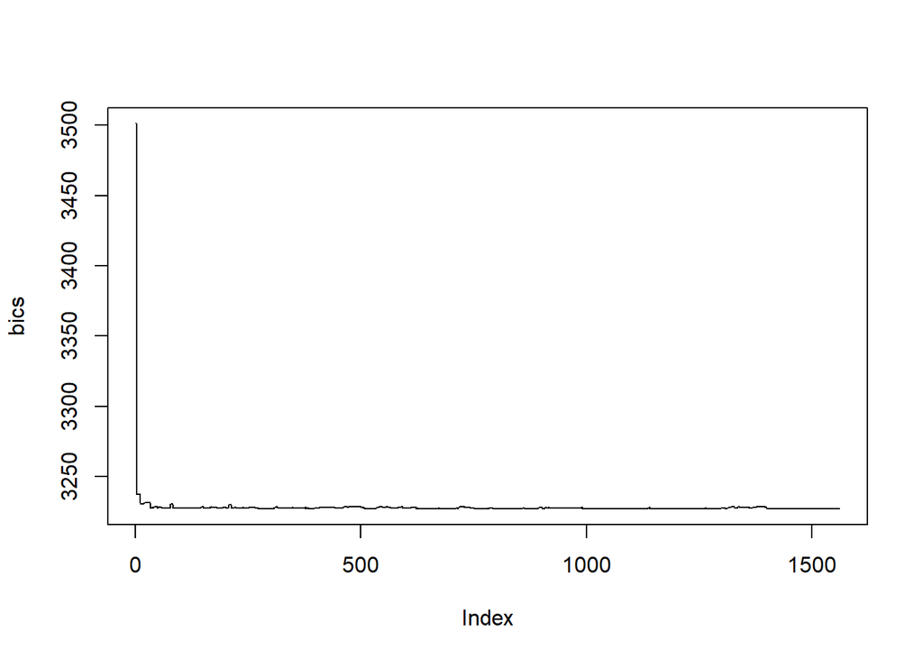

```r
plot(bics, type = "l")
```

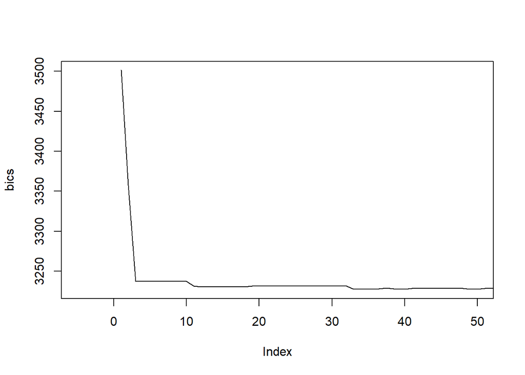

```r
plot(bics, type = "l", xlim = c(-5, 50))
```

```r
head(pos)
```

```
## [1] 10
```

b). Secon1dly, perform variable selection using the genetic algorithm in library GA. The binary type should be chosen. Other parameters should be set in order to find an appropriate genetic algorithm. Provide a plot of the fitness function over iterations (generations) and the selected variables in the final model. Compare with the results obtained in a).

```r
pred <- housing_data[-1:-2] #
y <- housing_data[1]

pred <- as.matrix(pred)
y <- as.matrix(y)
mod <- lm(y ~ pred,)
#mod <- lm(y ~ .,data=pred)
x <- model.matrix(mod)[, -1]
y <- model.response(model.frame(mod))
library(GA)
fitness <- function(string) {
    inc <- which(string == 1)
    X <- cbind(1, x[,inc])
    mod <- lm.fit(X, y)
    class(mod) <- "lm"
    -extractAIC(mod)[2]
}


GA <- ga("binary", fitness = fitness, nBits = ncol(x), names = colnames(x))
```

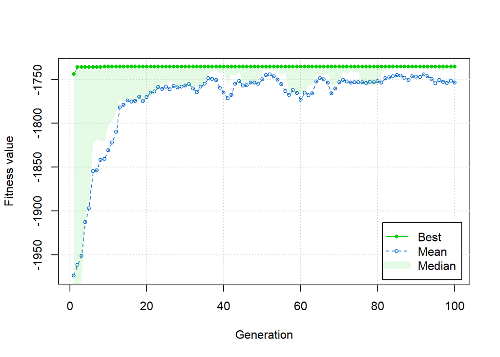

```r
plot(GA)
```

It would seem that convergence is achieved by the 40th generation.

```r
summary(GA)
```

```
## ── Genetic Algorithm ───────────────────
##
## GA settings:
## Type                  =  binary
## Population size       =  50
## Number of generations =  100
## Elitism               =  2
## Crossover probability =  0.8
## Mutation probability  =  0.1
##
## GA results:
## Iterations             = 100
## Fitness function value = -1735.409
## Solution =
##      predCRIM predZN predINDUS predCHAS predNOX predRM predAGE predDIS predRAD
## [1,]        1      1         0        1       0      1       1       1       1
##      predTAX predPTRATIO predB predLSTAT
## [1,]       1           1     1         1
```

On the last row ones meen that, that the variable was chosen in the final model. Only Indus and NOX variables were left out.